# FAT_LAB

### Reg. No: 18BCE1010

### Name: R. Harini

### Dataset: Credit Card

```r
rm(list=ls())
library(dplyr)
```

```r
library(ggplot2)
library(car)
library(caret)
df=read.csv("CreditCard.csv", stringsAsFactors = TRUE)
```

#### 1. Display the structure of the data set.

```r
str(df)
```

```
## 'data.frame':    1319 obs. of  13 variables:
##  $ X          : int  1 2 3 4 5 6 7 8 9 10 ...
##  $ card       : Factor w/ 2 levels "no","yes": 2 2 2 2 2 2 2 2 2 2 ...
##  $ reports    : int  0 0 0 0 0 0 0 0 0 0 ...
##  $ age        : num  37.7 33.2 33.7 30.5 32.2 ...
##  $ income     : num  4.52 2.42 4.5 2.54 9.79 ...
##  $ share      : num  0.03327 0.00522 0.00416 0.06521 0.06705 ...
##  $ expenditure: num  124.98 9.85 15 137.87 546.5 ...
##  $ owner      : Factor w/ 2 levels "no","yes": 2 1 2 1 2 1 1 2 2 1 ...
##  $ selfemp    : Factor w/ 2 levels "no","yes": 1 1 1 1 1 1 1 1 1 1 ...
##  $ dependents : int  3 3 4 0 2 0 2 0 0 0 ...
##  $ months     : int  54 34 58 25 64 54 7 77 97 65 ...
##  $ majorcards : int  1 1 1 1 1 1 1 1 1 1 ...
##  $ active     : int  12 13 5 7 5 1 5 3 6 18 ...
```

#### 2. Print the bottom 10 observations in the data set.

```r
tail(df,10)
```

```
##         X card reports      age income        share expenditure owner selfemp
## 1310 1310  yes       1 40.16667 2.0000 0.2548275000  424.629200   yes      no
## 1311 1311  yes       0 30.58333 2.5120 0.0026273890    4.583333    no     yes
## 1312 1312   no       0 39.33333 2.3004 0.0005216484    0.000000    no     yes
## 1313 1313   no       0 22.58333 3.8600 0.0003108808    0.000000    no      no
## 1314 1314   no       1 30.33333 2.1800 0.0005504587    0.000000    no     yes
## 1315 1315  yes       0 33.58333 4.5660 0.0021462990    7.333333   yes      no
## 1316 1316   no       5 23.91667 3.1920 0.0003759399    0.000000    no      no
## 1317 1317  yes       0 40.58333 4.6000 0.0265126100  101.298300   yes      no
## 1318 1318  yes       0 32.83333 3.7000 0.0089989190   26.996670    no     yes
## 1319 1319  yes       0 48.25000 3.7000 0.1116186000  344.157500   yes      no
##      dependents months majorcards active
## 1310          1    121          1     10
## 1311          3     36          0      4
## 1312          0     46          1      3
## 1313          1     36          0      4
## 1314          0     13          1      1
## 1315          0     94          1     19
## 1316          3     12          1      5
## 1317          2      1          1      2
## 1318          0     60          1      7
## 1319          2      2          1      0
```

#### 3. Display the summary statistics of the variables income share and expenditure.

```r
summary(df$income)
```

```
##    Min. 1st Qu.  Median    Mean 3rd Qu.    Max.
##   0.210   2.244   2.900   3.365   4.000  13.500
```

```r
summary(df$share)
```

```
##      Min.   1st Qu.    Median      Mean   3rd Qu.      Max.
## 0.0001091 0.0023159 0.0388272 0.0687322 0.0936168 0.9063205
```

```r
summary(df$expenditure)
```

```
##     Min.  1st Qu.   Median     Mean  3rd Qu.     Max.
##    0.000    4.583  101.298  185.057  249.036 3099.505
```

#### 4. Print the average income, median share and minimum expenditure for the applicants who do not own a house and had their application rejected.

```r
d=df%>%
  filter(owner=='no' & card=='no')
mean(d$income)
```

```
## [1] 2.805295
```

```r
median(d$share)
```

```
## [1] 0.000489847
```

```r
min(d$expenditure)
```

```
## [1] 0
```

#### 5. Do a random sampling of 15 data and plot to observe any outlier in the income? Justify your answer by appropriate plot and inference.

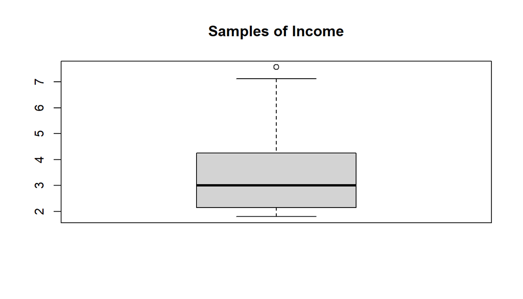

```r
s=sample(df$income, size=15)
boxplot(s, main="Samples of Income")
```

##### Since there are points visible above the top-most horizontal line, we can infer that outliers are present in the Income variable

#### 6. Find the standard deviation of income

```r
sd(df$income)
```

```
## [1] 1.693902
```

#### 7. Create a new column called income_cat which would have 3 labels as low, medium and high according to the income <=2.5, income >=2.5 and income<=4 and age>4 respectively.

```r
newdf=df%>%
  mutate(income_cat=case_when(income<=2.5~"low",
                   income>=2.5 & income<=4~"medium",
                   income>4~"high"))
colnames(newdf)
```

```
##  [1] "X"           "card"        "reports"     "age"         "income"
##  [6] "share"       "expenditure" "owner"       "selfemp"     "dependents"
## [11] "months"      "majorcards"  "active"      "income_cat"
```

```r
head(newdf$income_cat,10)
```

```
##  [1] "high"   "low"    "high"   "medium" "high"   "low"    "medium" "low"
##  [9] "medium" "medium"
```

#### 8. Identify which income category applicants have their applications mostly rejected.

```r
t=newdf%>%
  filter(card=="no")
max(table(t$income_cat))
```

```
## [1] 142
```

```r
which.max(table(t$income_cat))[1]
```

```
## low
##   2
```

##### The Low income category applicants have their applications mostly rejected. (freq= 142)

#### 9. Is there any low income self-employed applicants with own house got their application accepted?

```r
newdf%>%
  filter(income_cat=="low" & owner=="yes" & selfemp=="yes" & card=="yes")
```

```
##      X card reports      age income     share expenditure owner selfemp
## 1  146  yes       0 30.33333  2.500 0.0356228   73.797500   yes     yes
## 2  343  yes       0 56.91667  1.920 0.2004224  320.675800   yes     yes
## 3  421  yes       0 20.83333  2.000 0.0047500    7.083333   yes     yes
## 4 1036  yes       0 24.75000  2.000 0.0549975   91.412500   yes     yes
## 5 1115  yes       0 37.66667  2.385 0.1676499  332.704200   yes     yes
##   dependents months majorcards active income_cat
## 1          3     30          1      9        low
## 2          1     64          1      9        low
## 3          0     18          0      3        low
## 4          1     24          0     10        low
## 5          0    168          1     13        low
```

##### Yes there are 5 people satisfying all the conditions.

#### 10. What is the frequency and relative frequency distribution of applicants owning and not owning house?

```r
freq=table(df$owner)
freq
```

```
##
##  no yes
## 738 581
```

```r
rel_freq=freq/nrow(df)
rel_freq
```

```
##
##        no       yes
## 0.5595148 0.4404852
```

#### 11. Provide visualization of frequency distribution of applicants owning and not owning house.

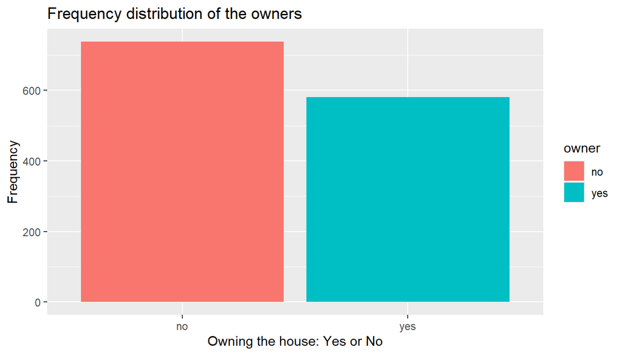

```r
ggplot(df, aes(x=owner, fill=owner))+geom_bar()+ggtitle("Frequency distribution of the owners")+xlab("Owning the house: Yes or No")+ylab("Frequency")
```

#### 12. Does the income and expenditure of the applicants correlated? Justify your answer.

```r
cor(df$income, df$expenditure)
```

```
## [1] 0.281104
```

##### The variables are mildly correlated as the correlation coefficient is above 0 but still well below 0.5.

#### 13. Predict the value of expenditure based on other numerical values and compare various models with different combination of variables. Suggest a model with limited dependent variables that is better according to you. Justify your analysis.

```r
# Drop the ID column
data=df[,2:13]

set.seed(123)
train_samples <- data$expenditure %>%
  createDataPartition(p=0.8,list=FALSE)

train <- data[train_samples,]
test <- data[-train_samples,]

model1=lm(expenditure~.,data=train)
summary(model1)
```

```
##
## Call:
## lm(formula = expenditure ~ ., data = train)
##
## Residuals:
##     Min      1Q  Median      3Q     Max
## -586.57  -31.47    5.11   33.89 1876.69
##
## Coefficients:
##               Estimate Std. Error t value Pr(>|t|)
## (Intercept) -181.53735   17.22775 -10.537  < 2e-16 ***
## cardyes       -4.54800   11.13482  -0.408  0.68303
## reports       -2.34856    3.20656  -0.732  0.46407
## age            0.84405    0.44081   1.915  0.05579 .
## income        48.29047    2.36104  20.453  < 2e-16 ***
## share       2529.48388   43.41589  58.262  < 2e-16 ***
## owneryes      -6.65934    8.70516  -0.765  0.44445
## selfempyes     2.67059   14.04077   0.190  0.84919
## dependents     5.20269    3.19487   1.628  0.10373
## months        -0.16598    0.06197  -2.679  0.00751 **
## majorcards     4.22485    9.71412   0.435  0.66371
## active         1.24870    0.63956   1.952  0.05115 .
## ---
## Signif. codes:  0 '***' 0.001 '**' 0.01 '*' 0.05 '.' 0.1 ' ' 1
##
## Residual standard error: 119.8 on 1045 degrees of freedom
## Multiple R-squared:  0.8109, Adjusted R-squared:  0.8089
## F-statistic: 407.3 on 11 and 1045 DF,  p-value: < 2.2e-16
```

```r
pred=model1%>%
  predict(test)
```

```r
RMSE(pred,test$expenditure)
```

```
## [1] 114.5635
```

```r
R2(pred,test$expenditure)
```

```
## [1] 0.8193449
```

```r
confint(model1)
```

```
##                     2.5 %        97.5 %
## (Intercept) -2.153423e+02 -147.73242804
## cardyes     -2.639716e+01   17.30115395
## reports     -8.640595e+00    3.94346916
## age         -2.091095e-02    1.70902053
## income       4.365755e+01   52.92339766
## share        2.444292e+03 2614.67613690
## owneryes    -2.374092e+01   10.42224247
## selfempyes  -2.488072e+01   30.22190891
## dependents  -1.066399e+00   11.47177608
## months      -2.875725e-01   -0.04439205
## majorcards  -1.483656e+01   23.28625953
## active      -6.269471e-03    2.50367755
```

```r
vif(model1)
```

```
##       card    reports        age     income      share      owner    selfemp
##   1.584732   1.398808   1.476695   1.283582   1.213056   1.379768   1.028136
## dependents     months majorcards     active
##   1.191850   1.248493   1.029657   1.191609
```

##### Since all the values are less than 5, we needn’t remove any variables yet.

#### Model 2

```r
#Removing the least significant variables from the model
model2=lm(expenditure~.-selfemp-card-majorcards, data=train)
summary(model2)
```

```
##
## Call:
## lm(formula = expenditure ~ . - selfemp - card - majorcards, data = train)
##
## Residuals:
##     Min      1Q  Median      3Q     Max
## -583.70  -31.67    4.57   33.96 1878.09
##
## Coefficients:
##              Estimate Std. Error t value Pr(>|t|)
## (Intercept) -181.0177    14.2834 -12.673  < 2e-16 ***
## reports       -1.7634     2.8261  -0.624  0.53279
## age            0.8403     0.4396   1.912  0.05621 .
## income        48.3354     2.3266  20.775  < 2e-16 ***
## share       2523.5217    40.4083  62.451  < 2e-16 ***
## owneryes      -6.9180     8.6573  -0.799  0.42442
## dependents     5.2486     3.1803   1.650  0.09917 .
## months        -0.1666     0.0618  -2.696  0.00713 **
## active         1.2226     0.6270   1.950  0.05145 .
## ---
## Signif. codes:  0 '***' 0.001 '**' 0.01 '*' 0.05 '.' 0.1 ' ' 1
##
## Residual standard error: 119.6 on 1048 degrees of freedom
## Multiple R-squared:  0.8108, Adjusted R-squared:  0.8094
## F-statistic: 561.4 on 8 and 1048 DF,  p-value: < 2.2e-16
```

```r
pred2=model2%>%
  predict(test)
```

```r
RMSE(pred2, test$expenditure)
```

```
## [1] 114.2301
```

```r
R2(pred2,test$expenditure)
```

```
## [1] 0.8203477
```

#### Model 3

```r
model3=lm(expenditure~
            age+dependents+months+active,data=train)
summary(model3)
```

```
##
## Call:
## lm(formula = expenditure ~ age + dependents + months + active,
##     data = train)
##
## Residuals:
##     Min      1Q  Median      3Q     Max
## -276.15 -163.18  -81.24   64.73 2889.55
##
## Coefficients:
##              Estimate Std. Error t value Pr(>|t|)
## (Intercept) 164.72675   29.65320   5.555 3.51e-08 ***
## age           0.01628    0.94866   0.017   0.9863
## dependents    9.34181    6.85461   1.363   0.1732
## months       -0.17194    0.14060  -1.223   0.2217
## active        2.65159    1.36195   1.947   0.0518 .
## ---
## Signif. codes:  0 '***' 0.001 '**' 0.01 '*' 0.05 '.' 0.1 ' ' 1
##
## Residual standard error: 273.5 on 1052 degrees of freedom
## Multiple R-squared:  0.007221,   Adjusted R-squared:  0.003446
## F-statistic: 1.913 on 4 and 1052 DF,  p-value: 0.1061
```

```r
pred3=model3%>%
  predict(test)
```

```r
RMSE(pred3, test$expenditure)
```

```
## [1] 264.7807
```

```r
R2(pred3, test$expenditure)
```

```
## [1] 0.003836994
```

#### Model 4

```r
model4=lm(expenditure~log(share)*age*income*dependents,data=train)
summary(model4)
```

```
##
## Call:
## lm(formula = expenditure ~ log(share) * age * income * dependents,
##     data = train)
##
## Residuals:
##     Min      1Q  Median      3Q     Max
## -452.99 -110.59  -42.13   71.00 1707.19
##
## Coefficients:
##                                  Estimate Std. Error t value Pr(>|t|)
## (Intercept)                      477.6268   117.3611   4.070 5.06e-05 ***
## log(share)                        75.2255    23.2134   3.241  0.00123 **
## age                              -10.8575     3.5424  -3.065  0.00223 **
## income                            48.1876    35.7901   1.346  0.17847
## dependents                       -11.4070    99.2223  -0.115  0.90850
## log(share):age                    -1.4943     0.6540  -2.285  0.02252 *
## log(share):income                  8.0835     6.9924   1.156  0.24793
## age:income                         1.6956     0.9479   1.789  0.07395 .
## log(share):dependents              9.3571    18.7819   0.498  0.61845
## age:dependents                    -0.1869     2.7850  -0.067  0.94652
## income:dependents                 -9.7845    24.0037  -0.408  0.68363
## log(share):age:income              0.1665     0.1720   0.968  0.33312
## log(share):age:dependents         -0.4604     0.5305  -0.868  0.38568
## log(share):income:dependents      -6.8505     4.4810  -1.529  0.12662
## age:income:dependents              0.3638     0.6459   0.563  0.57344
## log(share):age:income:dependents   0.2340     0.1208   1.937  0.05303 .
## ---
## Signif. codes:  0 '***' 0.001 '**' 0.01 '*' 0.05 '.' 0.1 ' ' 1
##
## Residual standard error: 194.3 on 1041 degrees of freedom
## Multiple R-squared:  0.5039, Adjusted R-squared:  0.4968
## F-statistic:  70.5 on 15 and 1041 DF,  p-value: < 2.2e-16
```

```r
pred4=model4%>%
  predict(test)
```

```r
RMSE(pred4,test$expenditure)
```

```
## [1] 182.083
```

```r
R2(pred4,test$expenditure)
```

```
## [1] 0.5333097
```

#### Model 5

```r
# Using only the most significant variables from model 1
model5=lm(expenditure~
            income*share*months*active, data=train)
summary(model5)
```

```
##
## Call:
## lm(formula = expenditure ~ income * share * months * active,
##     data = train)
##
## Residuals:
##      Min       1Q   Median       3Q      Max
## -1.46485 -0.31035  0.03733  0.25562  0.57206
##
## Coefficients:
##                              Estimate Std. Error  t value Pr(>|t|)
## (Intercept)                -6.671e-01  4.548e-02  -14.668  < 2e-16 ***
## income                      2.405e-02  1.245e-02    1.932 0.053667 .
## share                       1.517e+00  3.972e-01    3.821 0.000141 ***
## months                     -5.050e-04  5.051e-04   -1.000 0.317690
## active                     -3.144e-03  5.666e-03   -0.555 0.579043
## income:share                8.334e+02  1.244e-01 6699.855  < 2e-16 ***
## income:months              -1.164e-04  9.873e-05   -1.179 0.238867
## share:months               -9.745e-03  5.955e-03   -1.636 0.102082
## income:active               8.237e-04  1.434e-03    0.574 0.565877
## share:active                1.425e-01  4.885e-02    2.916 0.003620 **
## months:active               3.389e-05  6.952e-05    0.488 0.625966
## income:share:months         8.546e-03  2.035e-03    4.199 2.91e-05 ***
## income:share:active        -1.685e-02  1.346e-02   -1.252 0.210848
## income:months:active        9.187e-07  1.389e-05    0.066 0.947275
## share:months:active         1.733e-04  4.445e-04    0.390 0.696712
## income:share:months:active -3.560e-04  1.425e-04   -2.498 0.012636 *
## ---
## Signif. codes:  0 '***' 0.001 '**' 0.01 '*' 0.05 '.' 0.1 ' ' 1
##
## Residual standard error: 0.3075 on 1041 degrees of freedom
## Multiple R-squared:      1,  Adjusted R-squared:      1
## F-statistic: 5.589e+07 on 15 and 1041 DF,  p-value: < 2.2e-16
```

```r
pred5=model5%>%
  predict(test)
```

```r
RMSE(pred5,test$expenditure)
```

```
## [1] 0.3235212
```

```r
R2(pred5,test$expenditure)
```

```
## [1] 0.9999985
```

```r
model6=lm(expenditure~
            card*income*selfemp*majorcards,data=train)
summary(model6)
```

```
##
## Call:
## lm(formula = expenditure ~ card * income * selfemp * majorcards,
##     data = train)
##
## Residuals:
##     Min      1Q  Median      3Q     Max
## -630.48 -129.08    0.00   18.84 2403.70
##
## Coefficients:
##                                        Estimate Std. Error t value Pr(>|t|)
## (Intercept)                          -4.028e-12  6.780e+01   0.000   1.0000
## cardyes                               1.481e+02  8.685e+01   1.705   0.0884 .
## income                                1.391e-12  2.057e+01   0.000   1.0000
## selfempyes                            7.209e-12  2.247e+02   0.000   1.0000
## majorcards                            7.386e-12  8.075e+01   0.000   1.0000
## cardyes:income                        1.395e+01  2.592e+01   0.538   0.5907
## cardyes:selfempyes                   -1.917e+02  3.477e+02  -0.551   0.5815
## income:selfempyes                    -2.393e-12  5.740e+01   0.000   1.0000
## cardyes:majorcards                   -7.838e+01  9.960e+01  -0.787   0.4315
## income:majorcards                    -1.899e-12  2.404e+01   0.000   1.0000
## selfempyes:majorcards                -1.096e-11  2.492e+02   0.000   1.0000
## cardyes:income:selfempyes             4.674e+01  9.640e+01   0.485   0.6279
## cardyes:income:majorcards             3.614e+01  2.926e+01   1.235   0.2170
## cardyes:selfempyes:majorcards         1.206e+02  3.755e+02   0.321   0.7482
## income:selfempyes:majorcards          3.089e-12  6.326e+01   0.000   1.0000
## cardyes:income:selfempyes:majorcards -4.442e+01  1.017e+02  -0.437   0.6623
## ---
## Signif. codes:  0 '***' 0.001 '**' 0.01 '*' 0.05 '.' 0.1 ' ' 1
##
## Residual standard error: 245.6 on 1041 degrees of freedom
## Multiple R-squared:  0.2078, Adjusted R-squared:  0.1964
## F-statistic:  18.2 on 15 and 1041 DF,  p-value: < 2.2e-16
```

```r
pred6=model6%>%
  predict(test)
RMSE(pred6,test$expenditure)
```

```
## [1] 235.9263
```

```r
R2(pred6,test$expenditure)
```

```
## [1] 0.2160961
```

### On comparing the 6 models, Model 5 performed the best with its high Adjusted R-Squared (1) and low RMSE (0.32) as compared with other models.

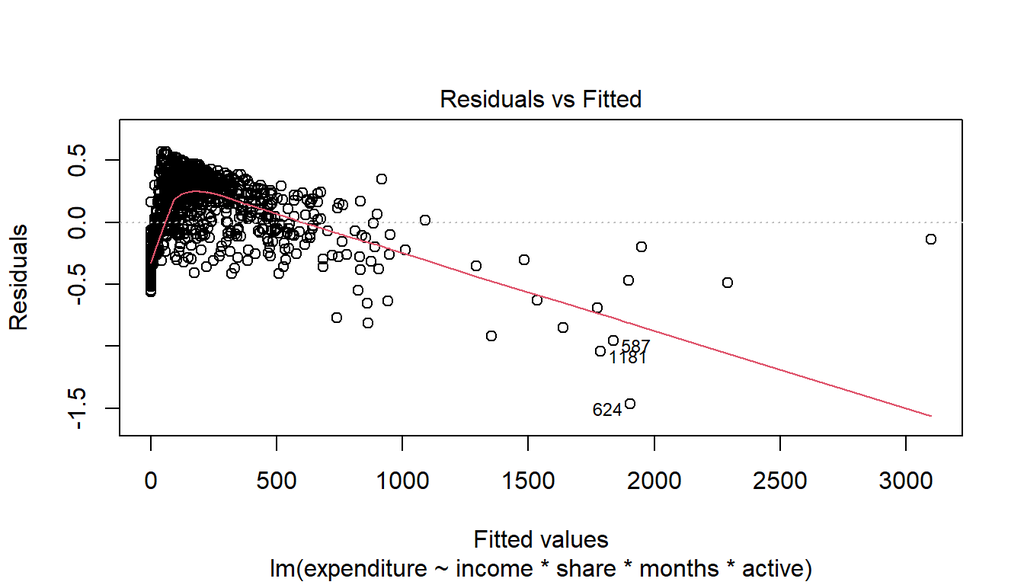

```r
# You can view the points following the line in the first plot.
plot(model5,1)
```

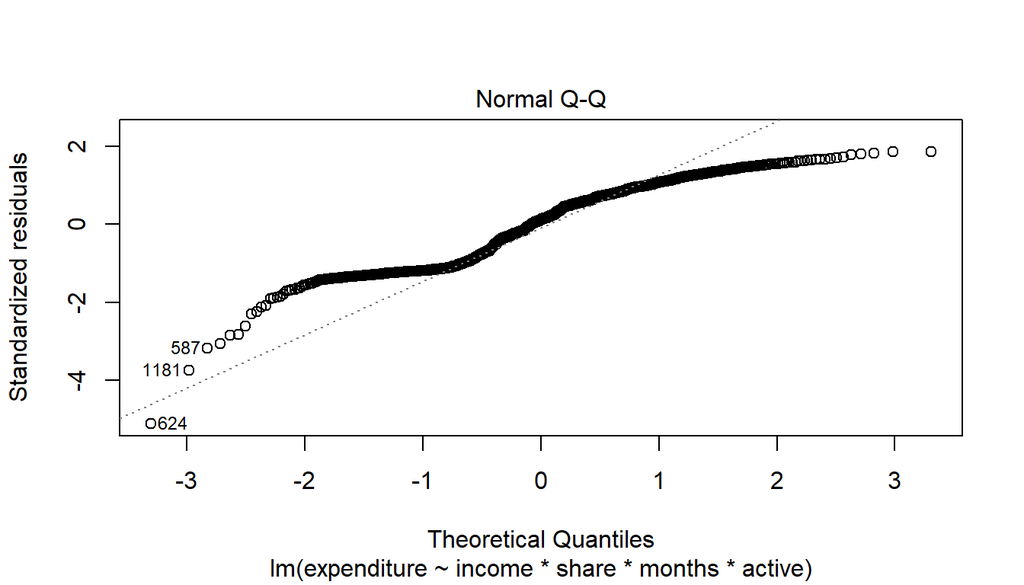

```r
plot(model5,2)
```

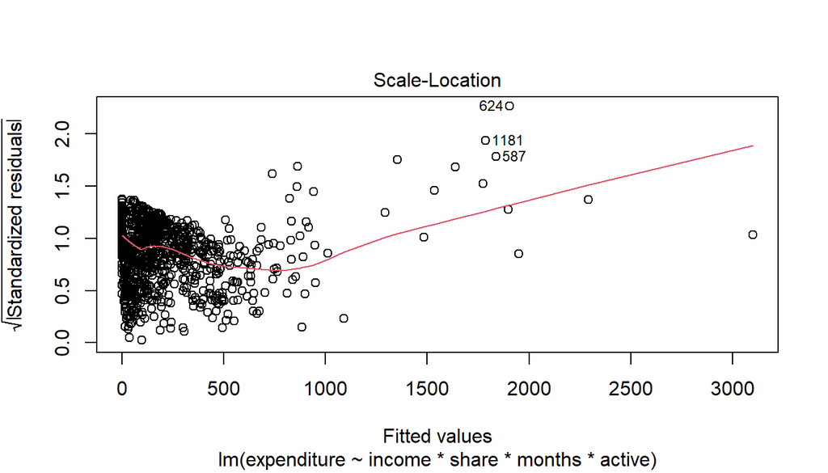

```r
plot(model5,3)
```

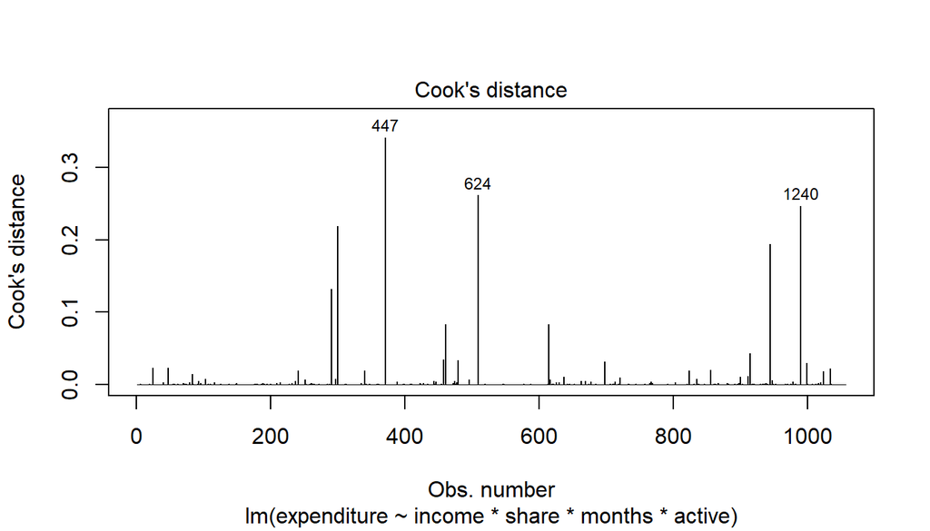

```r
plot(model5,4)
```